# ReCell Project - Supervised Learning

### Index

- Problem Statement
- Explore the dataset, Data Preprocessing and extract insights using Exploratory Data Analysis
- Questions on Exploratory Data Analysis(EDA)
- Building a Linear Regression model (sklearn)
- Linear Regression using statsmodels
- Checking Linear Regression Assumptions
- Final Model Summary
- Actionable Insights and Recommendations

## **1. Problem Statement**

#### Context

Buying and selling used smartphones used to be something that happened on a handful of online marketplace sites. But the used and refurbished phone market has grown considerably over the past decade, and a new IDC (International Data Corporation) forecast predicts that the used phone market would be worth $52.7bn by 2023 with a compound annual growth rate (CAGR) of 13.6% from 2018 to 2023. This growth can be attributed to an uptick in demand for used smartphones that offer considerable savings compared with new models.

Refurbished and used devices continue to provide cost-effective alternatives to both consumers and businesses that are looking to save money when purchasing a smartphone. There are plenty of other benefits associated with the used smartphone market. Used and refurbished devices can be sold with warranties and can also be insured with proof of purchase. Third-party vendors/platforms, such as Verizon, Amazon, etc., provide attractive offers to customers for refurbished smartphones. Maximizing the longevity of mobile phones through second-hand trade also reduces their environmental impact and helps in recycling and reducing waste. The impact of the COVID-19 outbreak may further boost the cheaper refurbished smartphone segment, as consumers cut back on discretionary spending and buy phones only for immediate needs.

#### Objective

The rising potential of this comparatively under-the-radar market fuels the need for an ML-based solution to develop a dynamic pricing strategy for used and refurbished smartphones. ReCell, a startup aiming to tap the potential in this market, has hired you as a data scientist. They want you to analyze the data provided and build a linear regression model to predict the price of a used phone and identify factors that significantly influence it.

#### Data Dictionary

- brand_name: Name of manufacturing brand
- os: OS on which the phone runs
- screen_size: Size of the screen in cm
- 4g: Whether 4G is available or not
- 5g: Whether 5G is available or not
- main_camera_mp: Resolution of the rear camera in megapixels
- selfie_camera_mp: Resolution of the front camera in megapixels
- int_memory: Amount of internal memory (ROM) in GB
- ram: Amount of RAM in GB
- battery: Energy capacity of the phone battery in mAh
- weight: Weight of the phone in grams
- release_year: Year when the phone model was released
- days_used: Number of days the used/refurbished phone has been used
- new_price: Price of a new phone of the same model in euros
- used_price: Price of the used/refurbished phone in euros

### Importing the required libraries

```python
# Ignore warnings
import warnings as wns
wns.filterwarnings('ignore')
```

```python
# import the important packages
# library used for data manipulation and analysis
import pandas as pd
# library used for working with arrays.
import numpy as np
# library for plots and visualisations
import matplotlib.pyplot as plt
import seaborn as sns
%matplotlib inline

# library to split the data into train and test
from sklearn.model_selection import train_test_split

# library to build linear regression_model
from sklearn.linear_model import LinearRegression

# library to check model performance
from sklearn.metrics import mean_absolute_error, mean_squared_error, r2_score

# library to build linear regression_model using statsmodels
import statsmodels.api as sm
```

```python
# Removing the limit of number of columns and rows printed
pd.set_option('display.max_columns',None) # Display all columns
pd.set_option('display.max_rows',200)# Display 200 rows.
```

## **2. Explore the dataset, Data Preprocessing and extract insights using Exploratory Data Analysis.**

### Load the input file and understand the structure of the data

```python
#Parser engine to use. The C engine is faster while the python engine is currently more feature-complete.
ReCell_df = pd.read_csv("used_phone_data.csv", engine="python")
```

```python
# Get the shape of the data.
print(f'The ReCell dataframe has {ReCell_df.shape[0]} rows and {ReCell_df.shape[1]} columns.')
```

```
The ReCell dataframe has 3571 rows and 15 columns.
```

```python
# Get a sample 10 rows of data using random state = 1
ReCell_df.sample(n=10, random_state=1)
```

|  | brand_name | os | screen_size | 4g | 5g | main_camera_mp | selfie_camera_mp | int_memory | ram | battery | weight | release_year | days_used | new_price | used_price |
| --- | --- | --- | --- | --- | --- | --- | --- | --- | --- | --- | --- | --- | --- | --- | --- |
| 2501 | Samsung | Android | 13.49 | yes | no | 13.0 | 13.0 | 32.0 | 4.00 | 3600.0 | 181.0 | 2017 | 683 | 198.680 | 79.47 |
| 2782 | Sony | Android | 13.81 | yes | no | NaN | 8.0 | 32.0 | 4.00 | 3300.0 | 156.0 | 2019 | 195 | 198.150 | 149.10 |
| 605 | Others | Android | 12.70 | yes | no | 8.0 | 5.0 | 16.0 | 4.00 | 2400.0 | 137.0 | 2015 | 1048 | 161.470 | 48.39 |
| 2923 | Vivo | Android | 19.37 | yes | no | 13.0 | 16.0 | 64.0 | 4.00 | 3260.0 | 149.3 | 2019 | 375 | 211.880 | 138.31 |
| 941 | Others | Others | 5.72 | no | no | 0.3 | 0.3 | 32.0 | 0.25 | 820.0 | 90.0 | 2013 | 883 | 29.810 | 8.92 |
| 1833 | LG | Android | 13.49 | no | no | 8.0 | 1.3 | 32.0 | 4.00 | 3140.0 | 161.0 | 2013 | 670 | 240.540 | 96.18 |
| 671 | Apple | iOS | 14.92 | yes | no | 12.0 | 7.0 | 64.0 | 4.00 | 5493.0 | 48.0 | 2018 | 403 | 700.150 | 350.08 |
| 1796 | LG | Android | 17.78 | yes | no | 5.0 | 0.3 | 16.0 | 4.00 | 4000.0 | 294.8 | 2014 | 708 | 189.300 | 75.94 |
| 757 | Asus | Android | 13.49 | yes | no | 13.0 | 8.0 | 32.0 | 4.00 | 5000.0 | 181.0 | 2017 | 612 | 270.500 | 108.13 |
| 3528 | Realme | Android | 15.72 | yes | no | NaN | 16.0 | 64.0 | 4.00 | 4035.0 | 184.0 | 2019 | 433 | 159.885 | 80.00 |

#### Observations:

The ReCell DataFrame has 15 columns as mentioned in the Data Dictionary. Data in each row corresponds to the features of each cell phone manufactured by different brands.

```python
# use info() method to print a concise summary of the pandas DataFrame
ReCell_df.info()
```

```
<class 'pandas.core.frame.DataFrame'>
RangeIndex: 3571 entries, 0 to 3570
Data columns (total 15 columns):
 #   Column            Non-Null Count  Dtype
---  ------            --------------  -----
 0   brand_name        3571 non-null   object
 1   os                3571 non-null   object
 2   screen_size       3571 non-null   float64
 3   4g                3571 non-null   object
 4   5g                3571 non-null   object
 5   main_camera_mp    3391 non-null   float64
 6   selfie_camera_mp  3569 non-null   float64
 7   int_memory        3561 non-null   float64
 8   ram               3561 non-null   float64
 9   battery           3565 non-null   float64
 10  weight            3564 non-null   float64
 11  release_year      3571 non-null   int64
 12  days_used         3571 non-null   int64
 13  new_price         3571 non-null   float64
 14  used_price        3571 non-null   float64
dtypes: float64(9), int64(2), object(4)
memory usage: 418.6+ KB
```

#### Observations:

The ReCell DataFrame has 15 columns - 4 of them are objects, 11 are numeric. We can also notice that 6 of the float columns have missing values - main_camera_mp, selfie_camera_mp, int_memory, ram, battery and weight.

```python
# using the describe() menthod to get the 5 point summary of the numerical columns in the dataframe.
# .T will transponse the table into a readable format with dataframe columns arranged in rows.
ReCell_df.describe().T
```

|  | count | mean | std | min | 25% | 50% | 75% | max |
| --- | --- | --- | --- | --- | --- | --- | --- | --- |
| screen_size | 3571.0 | 14.803892 | 5.153092 | 2.700 | 12.700 | 13.49 | 16.510 | 46.36 |
| main_camera_mp | 3391.0 | 9.400454 | 4.818396 | 0.080 | 5.000 | 8.00 | 13.000 | 48.00 |
| selfie_camera_mp | 3569.0 | 6.547352 | 6.879359 | 0.300 | 2.000 | 5.00 | 8.000 | 32.00 |
| int_memory | 3561.0 | 54.532607 | 84.696246 | 0.005 | 16.000 | 32.00 | 64.000 | 1024.00 |
| ram | 3561.0 | 4.056962 | 1.391844 | 0.030 | 4.000 | 4.00 | 4.000 | 16.00 |
| battery | 3565.0 | 3067.225666 | 1364.206665 | 80.000 | 2100.000 | 3000.00 | 4000.000 | 12000.00 |
| weight | 3564.0 | 179.424285 | 90.280856 | 23.000 | 140.000 | 159.00 | 184.000 | 950.00 |
| release_year | 3571.0 | 2015.964996 | 2.291784 | 2013.000 | 2014.000 | 2016.00 | 2018.000 | 2020.00 |
| days_used | 3571.0 | 675.391487 | 248.640972 | 91.000 | 536.000 | 690.00 | 872.000 | 1094.00 |
| new_price | 3571.0 | 237.389037 | 197.545581 | 9.130 | 120.130 | 189.80 | 291.935 | 2560.20 |
| used_price | 3571.0 | 109.880277 | 121.501226 | 2.510 | 45.205 | 75.53 | 126.000 | 1916.54 |

#### Observations:

This is the 5 point summary of 11 numerical columns.

1. For screen_size, the mean is 14.8 cm with a std deviation of 5.15. It is evident that the there are outliers as the max value is 46.36.
2. For main_camera_mp, the mean is 9.4 megapixels and median is 8 megapixels. The IQR is also 8 megapixels. The max value is 48 megapixels.
3. For selfie_camera_mp, the mean is 6.6 megapixels and median is 5 megapixels. The IQR is also 6 megapixels. The max value is 32 megapixels. It can be noted that the std deviation is 6.8.
4. For int_memory, the mean is 54.5 GB with a standard deviation of 84.6 and median is 32 GB. The IQR is also 48 GB. The min is 5 MB and max value is 1024 GB.
5. For ram, the mean is 4.1 GB with a standard deviation of 1.4 and median is 4 GB. The IQR is 0 GB. This means that more than 68% of the values in ram column is equal to 4 GB. After outlier treatment this column will be useless and it will contain only one value.
6. For battery, the mean is 3067 mAh with a standard deviation of 1364 and median is 3000 mAh. The IQR is also 1900 mAh. The min is 80 mAh and max value is 12000 mAh.
7. For weight, the mean is 179.4 grams with a standard deviation of 90.3 and median is 159 grams. The IQR is also 44 grams. The min is 23 grams and max value is 950 grams.
8. The value for release_year ranges from 2013 to 2020, and it appears like more than 50% of the data is concentrated on 2013 to 2015 (which makes sense as we are dealing with used cell phones.)
9. The value for days_used ranges from 91 days to 1094 days. The mean days used is 675 and median is 690, this looks like most of the data is concentrated on phones used for 536 to 872 days (IQR).
10. For new_price, the mean is 237.4 euros with a standard deviation of 197.5 and median is 189.8 euros. The IQR is also 170 euros. The min is 9 euros and max value is 2560 euros.
11. For the dependent variable used_price, the mean is 109.9 euros with a standard deviation of 121.5 and median is 75.5 euros. The IQR is also 80 euros. The min is 2.5 euros and max value is 1916.5 euros.

```python
# using the describe() menthod to get the 5 point summary
# using 'include' to inculde "object" and "category" columns in the dataframe.
# .T will transponse the table into a readable format with dataframe columns arranged in rows.
ReCell_df.describe(include='object').T
```

|  | count | unique | top | freq |
| --- | --- | --- | --- | --- |
| brand_name | 3571 | 34 | Others | 509 |
| os | 3571 | 4 | Android | 3246 |
| 4g | 3571 | 2 | yes | 2359 |
| 5g | 3571 | 2 | no | 3419 |

#### Observations:

1. For the column 'brand_name', it has 34 unique values - The most frequent one is 'Others', with a frequency of 509.
2. For the column 'os', it has 4 unique values - The most frequent one is 'Android', with a frequency of 3246.
3. For the column '4g', it has two unique values - no and yes. Yes appears more than No. 4G phones were more popular from 2013 to 2020.
4. For the column '5g', it has two unique values - no and yes. No appears more than Yes.

```python
# let's create a copy of the data to avoid any changes to original data
ReCell_Data = ReCell_df.copy()
```

### Data Preprocessing

#### Missing Value Treatment

```python
# checking for missing values
ReCell_Data.isnull().sum()
```

```
brand_name            0
os                    0
screen_size           0
4g                    0
5g                    0
main_camera_mp      180
selfie_camera_mp      2
int_memory           10
ram                  10
battery               6
weight                7
release_year          0
days_used             0
new_price             0
used_price            0
dtype: int64
```

#### Observations:

- Note that 6 of the float columns have missing values - main_camera_mp, selfie_camera_mp, int_memory, ram, battery and weight.
- We will replace the missing values in each column with its median.

```python
# function to replace  a column with it's median
medianfiller = lambda x:x.fillna(x.median())
# get the list of float columns from the dataframe as only float64 columns have missing values.
float_columns = ReCell_Data.select_dtypes(include=['float64']).columns.to_list()
# apply the function to the float columns in the dataframe.
ReCell_Data[float_columns] = ReCell_Data[float_columns].apply(medianfiller,axis=1)
```

```python
# checking for missing values again
ReCell_Data.isnull().sum()
```

```
brand_name          0
os                  0
screen_size         0
4g                  0
5g                  0
main_camera_mp      0
selfie_camera_mp    0
int_memory          0
ram                 0
battery             0
weight              0
release_year        0
days_used           0
new_price           0
used_price          0
dtype: int64
```

#### Observations:

```python
# using the describe() menthod to get the 5 point summary of the numerical columns in the dataframe.
# .T will transponse the table into a readable format with dataframe columns arranged in rows.
ReCell_Data.describe().T
```

|  | count | mean | std | min | 25% | 50% | 75% | max |
| --- | --- | --- | --- | --- | --- | --- | --- | --- |
| screen_size | 3571.0 | 14.803892 | 5.153092 | 2.700 | 12.700 | 13.49 | 16.510 | 46.36 |
| main_camera_mp | 3571.0 | 15.248925 | 28.437822 | 0.080 | 5.000 | 8.10 | 13.000 | 254.50 |
| selfie_camera_mp | 3571.0 | 6.608093 | 7.343711 | 0.300 | 2.000 | 5.00 | 8.000 | 124.00 |
| int_memory | 3571.0 | 54.417216 | 84.606282 | 0.005 | 16.000 | 32.00 | 64.000 | 1024.00 |
| ram | 3571.0 | 4.082919 | 1.513781 | 0.030 | 4.000 | 4.00 | 4.000 | 28.06 |
| battery | 3571.0 | 3062.099436 | 1368.776867 | 7.185 | 2100.000 | 3000.00 | 4000.000 | 12000.00 |
| weight | 3571.0 | 179.108741 | 90.473114 | 14.350 | 140.000 | 159.00 | 184.000 | 950.00 |
| release_year | 3571.0 | 2015.964996 | 2.291784 | 2013.000 | 2014.000 | 2016.00 | 2018.000 | 2020.00 |
| days_used | 3571.0 | 675.391487 | 248.640972 | 91.000 | 536.000 | 690.00 | 872.000 | 1094.00 |
| new_price | 3571.0 | 237.389037 | 197.545581 | 9.130 | 120.130 | 189.80 | 291.935 | 2560.20 |
| used_price | 3571.0 | 109.880277 | 121.501226 | 2.510 | 45.205 | 75.53 | 126.000 | 1916.54 |

#### Observations:

```python
# use info() method to print a concise summary of the pandas DataFrame
ReCell_Data.info()
```

```
<class 'pandas.core.frame.DataFrame'>
RangeIndex: 3571 entries, 0 to 3570
Data columns (total 15 columns):
 #   Column            Non-Null Count  Dtype
---  ------            --------------  -----
 0   brand_name        3571 non-null   object
 1   os                3571 non-null   object
 2   screen_size       3571 non-null   float64
 3   4g                3571 non-null   object
 4   5g                3571 non-null   object
 5   main_camera_mp    3571 non-null   float64
 6   selfie_camera_mp  3571 non-null   float64
 7   int_memory        3571 non-null   float64
 8   ram               3571 non-null   float64
 9   battery           3571 non-null   float64
 10  weight            3571 non-null   float64
 11  release_year      3571 non-null   int64
 12  days_used         3571 non-null   int64
 13  new_price         3571 non-null   float64
 14  used_price        3571 non-null   float64
dtypes: float64(9), int64(2), object(4)
memory usage: 418.6+ KB
```

#### Observations:

- Notice that all there are no null columns in the dataframe.

## Exploratory Data Analysis (EDA)

### Univariate Analysis

```python
# function to plot a boxplot and a histogram along the same scale.
# These are not mine, I borrowed this from Prof.Abhinanda Sarkar's notebook.
def histogram_boxplot(data, feature, figsize=(12, 7), kde=False, bins=None):
    """
    Boxplot and histogram combined

    data: dataframe
    feature: dataframe column
    figsize: size of figure (default (12,7))
    kde: whether to the show density curve (default False)
    bins: number of bins for histogram (default None)
    """
    f2, (ax_box2, ax_hist2) = plt.subplots(
        nrows=2,  # Number of rows of the subplot grid= 2
        sharex=True,  # x-axis will be shared among all subplots
        gridspec_kw={"height_ratios": (0.25, 0.75)},
        figsize=figsize,
    )  # creating the 2 subplots
    sns.boxplot(
        data=data, x=feature, ax=ax_box2, showmeans=True, color="violet"
    )  # boxplot will be created and a star will indicate the mean value of the column
    sns.histplot(
        data=data, x=feature, kde=kde, ax=ax_hist2, bins=bins, palette="winter"
    ) if bins else sns.histplot(
        data=data, x=feature, kde=kde, ax=ax_hist2
    )  # For histogram
    ax_hist2.axvline(
        data[feature].mean(), color="green", linestyle="--"
    )  # Add mean to the histogram
    ax_hist2.axvline(
        data[feature].median(), color="black", linestyle="-"
    )  # Add median to the histogram

# function to create labeled barplots
# These are not mine, I borrowed this from Prof.Abhinanda Sarkar's notebook.
def labeled_barplot(data, feature, perc=False, n=None):
    """
    Barplot with percentage at the top
    data: dataframe
    feature: dataframe column
    perc: whether to display percentages instead of count (default is False)
    n: displays the top n category levels (default is None, i.e., display all levels)
    """

    total = len(data[feature])  # length of the column
    count = data[feature].nunique()
    if n is None:
        plt.figure(figsize=(count + 1, 5))
    else:
        plt.figure(figsize=(n + 1, 5))

    plt.xticks(rotation=60, fontsize=10)
    ax = sns.countplot(
        data=data,
        x=feature,
        palette="Paired",
        order=data[feature].value_counts().index[:n].sort_values(),
    )

    for p in ax.patches:
        if perc == True:
            label = "{:.1f}%".format(
                100 * p.get_height() / total
            )  # percentage of each class of the category
        else:
            label = p.get_height()  # count of each level of the category

        x = p.get_x() + p.get_width() / 2  # width of the plot
        y = p.get_height()  # height of the plot

        ax.annotate(
            label,
            (x, y),
            ha="center",
            va="center",
            size=12,
            xytext=(0, 5),
            textcoords="offset points",
        )  # annotate the percentage

    plt.show()  # show the plot
```

#### Starting with the dependent variable used price

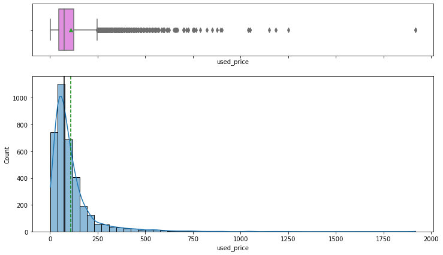

```python
# Display a histogram and boxplot with kde curve for the numeric column 'used_price'
histogram_boxplot(ReCell_Data, 'used_price', kde=True, bins=50)
```

#### Let's look at independent variables

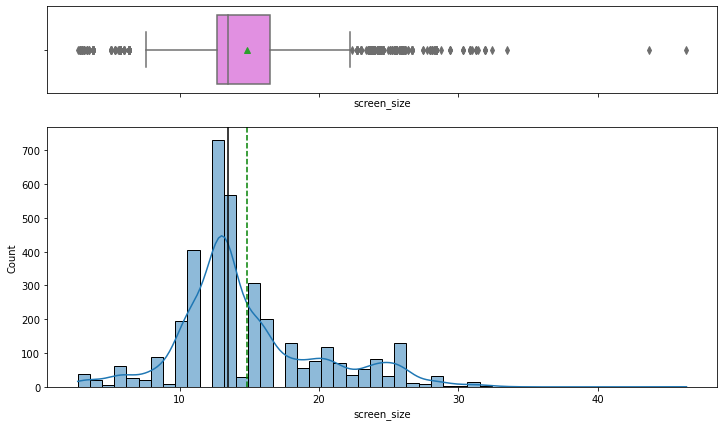

```python
# Display a histogram and boxplot with kde curve for the numeric column 'screen_size'
histogram_boxplot(ReCell_Data, 'screen_size', kde=True, bins=50)
```

#### Observations:

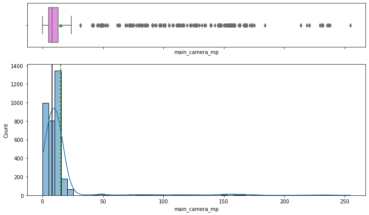

```python
# Display a histogram and boxplot with kde curve for the numeric column 'main_camera_mp'
histogram_boxplot(ReCell_Data, 'main_camera_mp', kde=True, bins=50)
```

#### Observations:

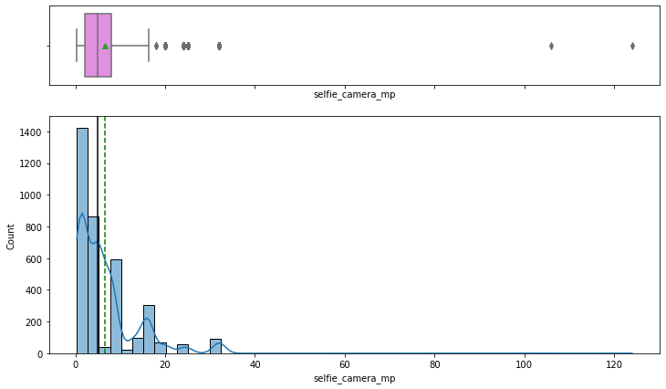

```python
# Display a histogram and boxplot with kde curve for the numeric column 'selfie_camera_mp'
histogram_boxplot(ReCell_Data, 'selfie_camera_mp', kde=True, bins=50)
```

#### Observations:

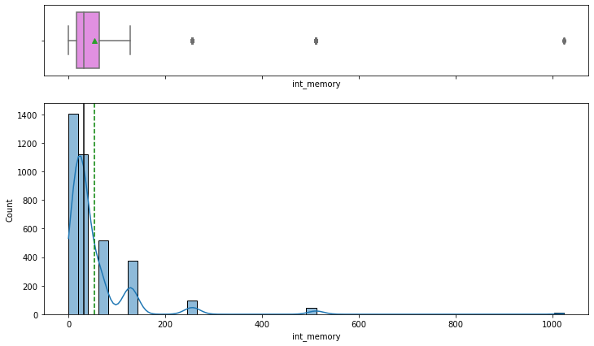

```python
# Display a histogram and boxplot with kde curve for the numeric column 'int_memory'
histogram_boxplot(ReCell_Data, 'int_memory', kde=True, bins=50)
```

#### Observations:

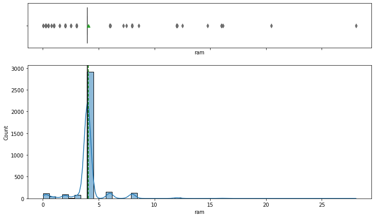

```python
# Display a histogram and boxplot with kde curve for the numeric column 'ram'
histogram_boxplot(ReCell_Data, 'ram', kde=True, bins=50)
```

#### Observations:

- There are plenty of outliers in the data as displayed in box plot.
- The mean is almost equal to median, that indicates the distribution is not skewed.
- About 68% of the values for 'ram' is equal to 4 GB.

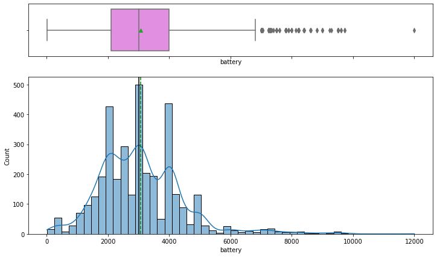

```python
# Display a histogram and boxplot with kde curve for the numeric column 'battery'
histogram_boxplot(ReCell_Data, 'battery', kde=True, bins=50)
```

#### Observations:

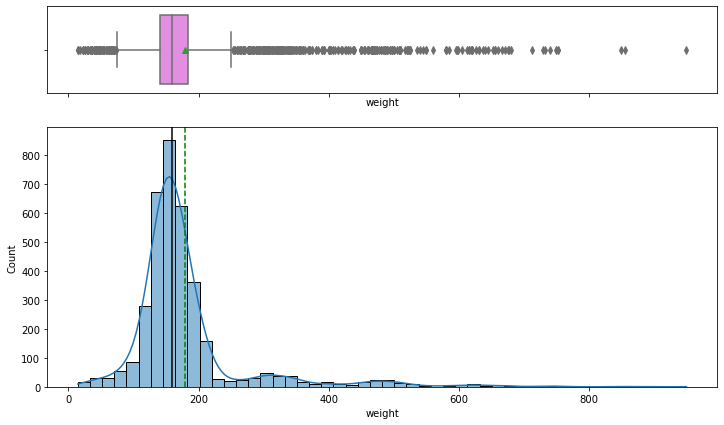

```python
# Display a histogram and boxplot with kde curve for the numeric column 'weight'
histogram_boxplot(ReCell_Data, 'weight', kde=True, bins=50)
```

#### Observations:

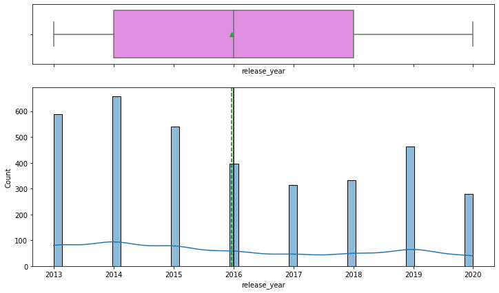

```python
# Display a histogram and boxplot with kde curve for the numeric column 'release_year'
histogram_boxplot(ReCell_Data, 'release_year', kde=True, bins=50)
```

#### Observations:

- There are no outliers in the data as displayed in box plot.
- The mean is almost equal than median, that indicates the distribution is not skewed.
- It appears like more than 50% of the data is concentrated on 2013 to 2015 (which makes sense as we are dealing with used cell phones.)

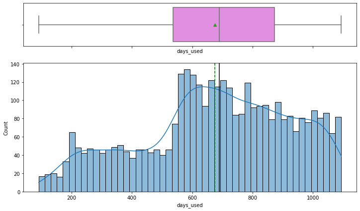

```python
# Display a histogram and boxplot with kde curve for the numeric column 'days_used'
histogram_boxplot(ReCell_Data, 'days_used', kde=True, bins=50)
```

#### Observations:

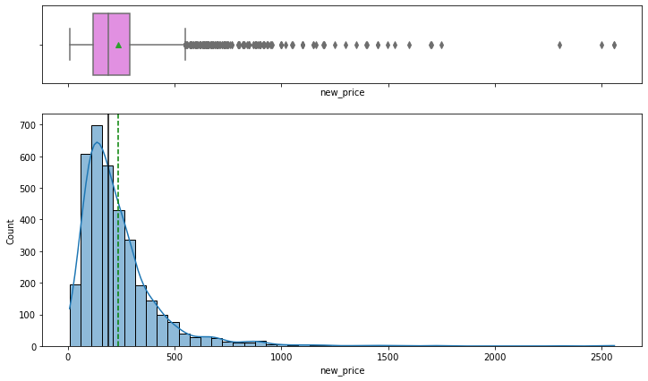

```python
# Display a histogram and boxplot with kde curve for the numeric column 'new_price'
histogram_boxplot(ReCell_Data, 'new_price', kde=True, bins=50)
```

#### Observations:

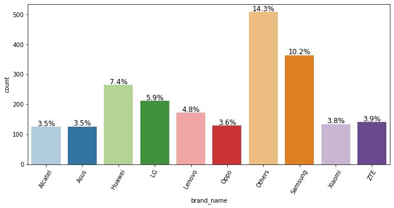

```python
# Display a labeled_barplot for the categorical column 'brand_name'
labeled_barplot(ReCell_Data, 'brand_name', perc=True, n=10)
```

#### Observations:

1. The field 'brand_name' has 34 unique values, one of them is "Others" that constitute to 14.3% of the data.
2. The next frequent brand is Samsung with 10.2%, followed by Huawei with 7.4%.

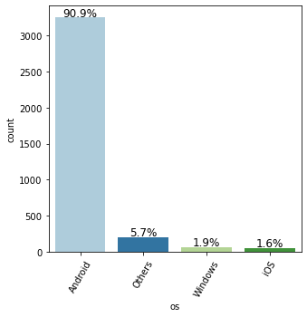

```python
# Display a labeled_barplot for the categorical column 'os'
labeled_barplot(ReCell_Data, 'os', perc=True)
```

#### Observations:

1. The field 'os' has 4 unique values, one of them is "Android" that constitute to 90.9% of the data.
2. The next frequest brand is Others with 5.7%, followed by Windows and iOS.

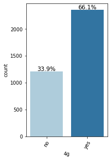

```python
# Display a labeled_barplot for the categorical column '4g'
labeled_barplot(ReCell_Data, '4g', perc=True)
```

#### Observations:

1. The field 4g has two unique values - yes and no.
2. There are 66.1% of observations with converted status = 'yes' and 33.9% of observations with converted status = 'no'

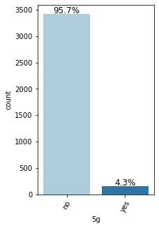

```python
# Display a labeled_barplot for the categorical column '5g'
labeled_barplot(ReCell_Data, '5g', perc=True)
```

#### Observations:

1. The field 5g has two unique values - yes and no.
2. There are 4.3% of observations with converted status = 'yes' and 95.7% of observations with converted status = 'no'
3. 5G phones started becoming popular only in late 2019.

### Bivariate and Multivariate Analysis

#### Starting with pairplot and heat map of numerical fields

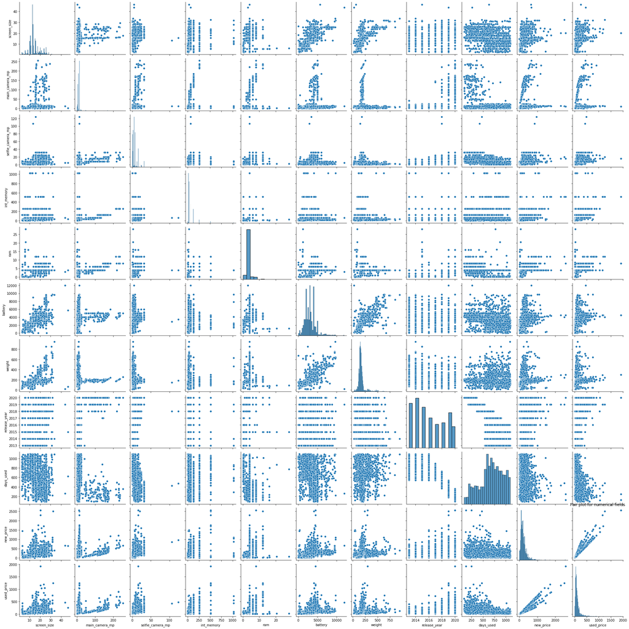

```python
# Display a pair plot to find the relationship between numerical fields.
plt.figure(figsize=(20,20))
sns.pairplot(ReCell_Data)

# Set the title for the plot
plt.title('Pair plot for numerical fields')
plt.show()
```

#### Observations:

1. Since we are targetting used_price, let's try to identify the variables that have correlation with used_price.

```python
# Print the correlation between numerical columns.
ReCell_Data.corr().round(3)
```

|  | screen_size | main_camera_mp | selfie_camera_mp | int_memory | ram | battery | weight | release_year | days_used | new_price | used_price |
| --- | --- | --- | --- | --- | --- | --- | --- | --- | --- | --- | --- |
| screen_size | 1.000 | 0.251 | 0.347 | 0.146 | 0.229 | 0.738 | 0.634 | 0.455 | -0.397 | 0.342 | 0.386 |
| main_camera_mp | 0.251 | 1.000 | 0.361 | 0.183 | 0.341 | 0.222 | 0.020 | 0.382 | -0.350 | 0.255 | 0.352 |
| selfie_camera_mp | 0.347 | 0.361 | 1.000 | 0.267 | 0.371 | 0.324 | -0.004 | 0.660 | -0.528 | 0.401 | 0.488 |
| int_memory | 0.146 | 0.183 | 0.267 | 1.000 | 0.066 | 0.116 | 0.020 | 0.220 | -0.229 | 0.344 | 0.406 |
| ram | 0.229 | 0.341 | 0.371 | 0.066 | 1.000 | 0.189 | 0.046 | 0.279 | -0.255 | 0.390 | 0.467 |
| battery | 0.738 | 0.222 | 0.324 | 0.116 | 0.189 | 1.000 | 0.696 | 0.458 | -0.354 | 0.341 | 0.364 |
| weight | 0.634 | 0.020 | -0.004 | 0.020 | 0.046 | 0.696 | 1.000 | 0.064 | -0.061 | 0.200 | 0.172 |
| release_year | 0.455 | 0.382 | 0.660 | 0.220 | 0.279 | 0.458 | 0.064 | 1.000 | -0.749 | 0.297 | 0.457 |
| days_used | -0.397 | -0.350 | -0.528 | -0.229 | -0.255 | -0.354 | -0.061 | -0.749 | 1.000 | -0.236 | -0.471 |
| new_price | 0.342 | 0.255 | 0.401 | 0.344 | 0.390 | 0.341 | 0.200 | 0.297 | -0.236 | 1.000 | 0.926 |
| used_price | 0.386 | 0.352 | 0.488 | 0.406 | 0.467 | 0.364 | 0.172 | 0.457 | -0.471 | 0.926 | 1.000 |

#### Observations:

1. Used_price is positively corelated with new_price, release_year, ram, selfie_camera_mp and int_memory.
2. Used_price is negatively corelated with days_used.
3. We will verify this using Linear models.

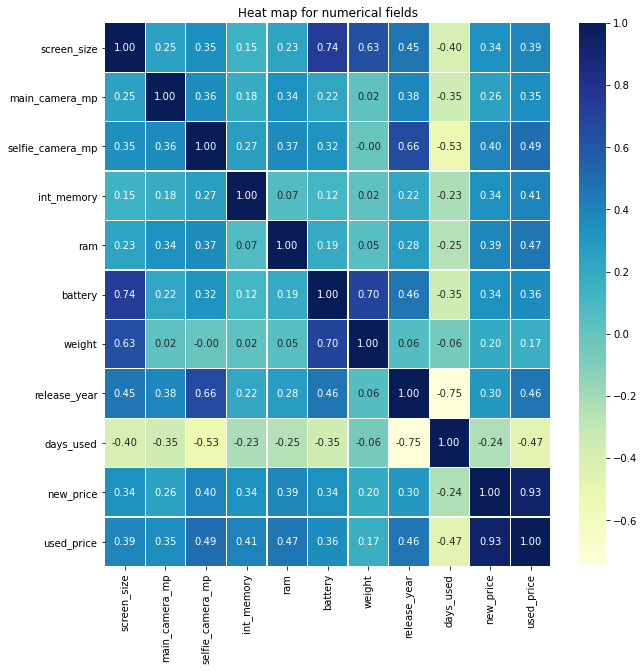

```python
# Set the figure size and title for the plot
plt.figure(figsize=(10,10))
plt.title('Heat map for numerical fields')

# Display a heat map to find the relationship between numerical fields.
sns.heatmap(ReCell_Data.corr(),annot=True,linewidths=0.2,fmt=".2f",cmap="YlGnBu")
plt.show()
```

#### Observations:

1. Used_price is highly positively corelated with new_price (0.93), which makes sense as the new price factors in for determining the used price of the phone.
2. Used_price is positively corelated with release_year (0.46). In other words, newer the phone, higher the price.
3. Used_price is positively corelated with ram (0.47), price increases as RAM memory is increased.
4. Used_price is positively corelated with selfie_camera_mp (0.49). In other words, higher the megapixels in selfie camera, higher the price.
5. Used_price is positively corelated with int_memory (0.41), price increases as internal memory is increased.
6. Used_price is negatively corelated with days_used (-0.47). The more the phone is used, the value goes down.

#### Bivariate analysis

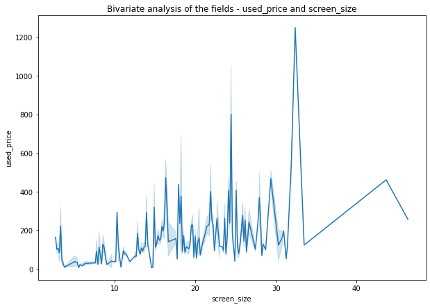

```python
# Set the figure size and title for the plot
plt.figure(figsize=(10,7))
plt.title('Bivariate analysis of the fields - used_price and screen_size')

# Line plot to compare used cell phone price vs screen size
sns.lineplot(x="screen_size",y="used_price",data=ReCell_Data)
plt.show()
```

#### Observations

1. As observed in the heat map, there is an overall price increase for increase in screen size.
2. But the line plot clearly displays the fluctuation on used price, it is not a linear curve and there by does not indicate a positive correlation.

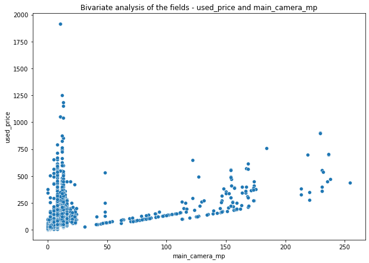

```python
# Set the figure size and title for the plot
plt.figure(figsize=(10,7))
plt.title('Bivariate analysis of the fields - used_price and main_camera_mp')

# Scatter plot to compare used cell phone price vs main camera mp
sns.scatterplot(x="main_camera_mp",y="used_price",data=ReCell_Data)
plt.show()
```

#### Observations

1. There is an overall price increase for increase in main camera megapixels.
2. This is especially true after the value of main camera megapixels crosses 40 mps.
3. For values of megapixels less than 40 mps, we cannot identify any correlation between data.

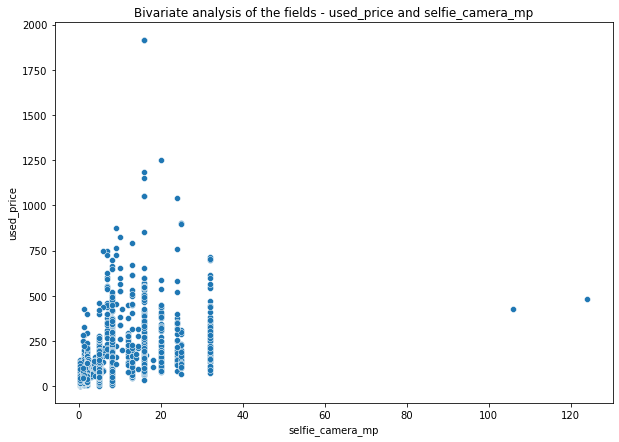

```python
# Set the figure size and title for the plot
plt.figure(figsize=(10,7))
plt.title('Bivariate analysis of the fields - used_price and selfie_camera_mp')

# Scatter plot to compare used cell phone price vs selfie camera mp
sns.scatterplot(x="selfie_camera_mp",y="used_price",data=ReCell_Data)
plt.show()
```

#### Observations

1. There is an overall price increase for increase in selfie camera megapixels.
2. It can also be noticed that there is range of prices offered for phones with same selfie camera megapixels.

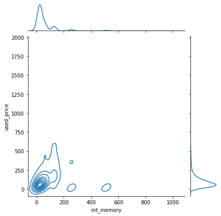

```python
# Set the figure size for the plot
plt.figure(figsize=(10,7))

# Joint kde plot to compare used cell phone price vs int memory
sns.jointplot(x="int_memory",y="used_price",data=ReCell_Data,kind='kde')
plt.show()
```

#### Observations

1. There is an overall price increase for increase in internal memory.
2. It can also be noticed that there is range of prices offered for phones with same amount of internal memory.

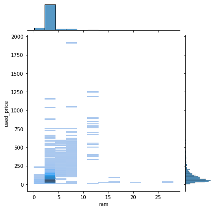

```python
# Set the figure size for the plot
plt.figure(figsize=(10,7))

# Joint hist plot to compare used cell phone price vs ram
sns.jointplot(x="ram",y="used_price",data=ReCell_Data,kind='hist')
plt.show()
```

#### Observations

1. There is an overall price increase for increase in ram.
2. It can also be noticed that there is range of prices offered for phones with same amount of ram.

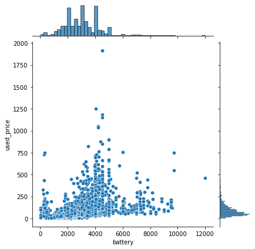

```python
# Set the figure size for the plot
plt.figure(figsize=(10,7))

# Joint scatter plot to compare used cell phone price vs battery
sns.jointplot(x="battery",y="used_price",data=ReCell_Data,kind='scatter')
plt.show()
```

#### Observations

1. There is an overall price increase for increase in battery capacity.
2. It can also be noticed that there is range of prices offered for phones with same amount of battery.

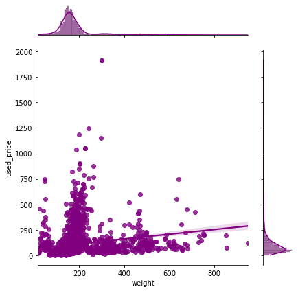

```python
# Set the figure size for the plot
plt.figure(figsize=(10,7))

# Joint reg plot to compare used cell phone price vs weight
sns.jointplot(x="weight",y="used_price",data=ReCell_Data,kind='reg',space=0.5,color='purple')
plt.show()
```

#### Observations

1. There is an overall price increase for increase in weight.
2. It can also be noticed that there is range of prices offered for phones with same amount of weight.

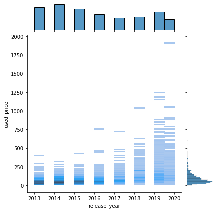

```python
# Set the figure size for the plot
plt.figure(figsize=(10,7))

# Joint hist plot to compare used cell phone price vs release year
sns.jointplot(x="release_year",y="used_price",data=ReCell_Data,kind='hist')
plt.show()
```

#### Observations

1. There price of the phone has increased over the years.
2. It can also be noticed that there is a higher price variation in as we move from 2013 calendar year to 2020.

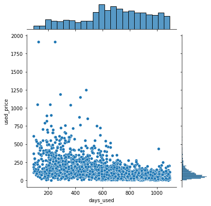

```python
# Set the figure size for the plot
plt.figure(figsize=(10,7))

# Scatter plot to compare used cell phone price vs days used
sns.jointplot(x="days_used",y="used_price",data=ReCell_Data,kind='scatter')
plt.show()
```

#### Observations

1. There is an overall price decrease for increase in the number of used days.
2. It can also be noticed that there is range of prices offered for phones with same amount of used days.

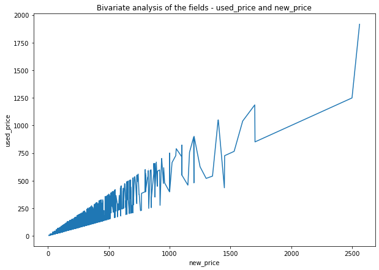

```python
# Set the figure size and title for the plot
plt.figure(figsize=(10,7))
plt.title('Bivariate analysis of the fields - used_price and new_price')

# Line plot to compare used cell phone price vs new price
sns.lineplot(x="new_price",y="used_price",data=ReCell_Data)
plt.show()
```

#### Observations

1. As observed in the heat map, there is a sharp increase in used phone price with increase in new price.
2. Used_price is highly positively corelated with new_price (0.93), which makes sense as the new price factors in for determining the used price of the phone.

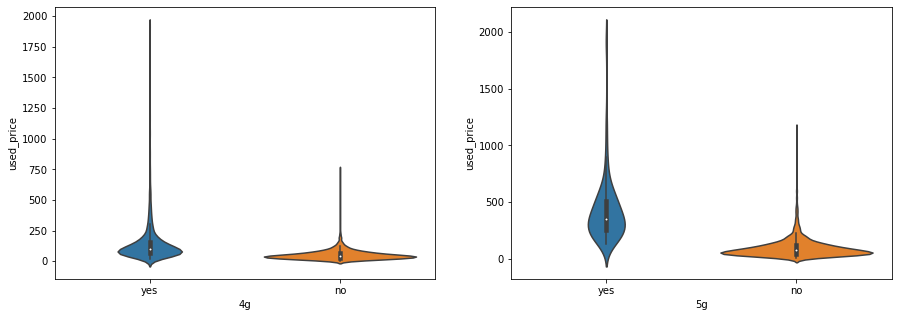

```python
# Set the figure size and title for the plot
plt.figure(figsize=(15, 5))
plt.title('Bivariate analysis of the fields using violin plot- used price and 4g/5g feature')

# Violin plot for analying the fields - used price and 4g/5g feature
plt.subplot(1, 2, 1)
sns.violinplot(data=ReCell_Data, y="used_price", x="4g", order=['yes','no'])

plt.subplot(1, 2, 2)
sns.violinplot(data=ReCell_Data, y="used_price", x="5g", order=['yes','no'])

plt.show()
```

#### Observations

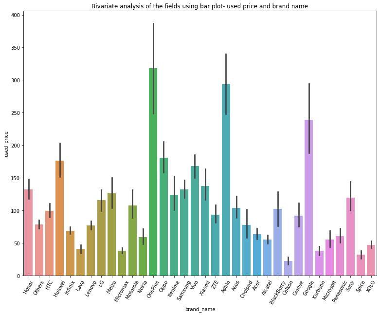

```python
# Set the figure size and title for the plot
plt.figure(figsize=(13,10))
plt.title('Bivariate analysis of the fields using bar plot- used price and brand name')

# Swarm plot for analying the fields - used price and brand name
sns.barplot(x="brand_name",y="used_price",data=ReCell_Data)
plt.xticks(rotation=60)
plt.show()
```

#### Observations

1. OnePlus, Apple and Google has high used prices compared to other brands.
2. Lava, Micormax, Celkon and Spice had low used prices.

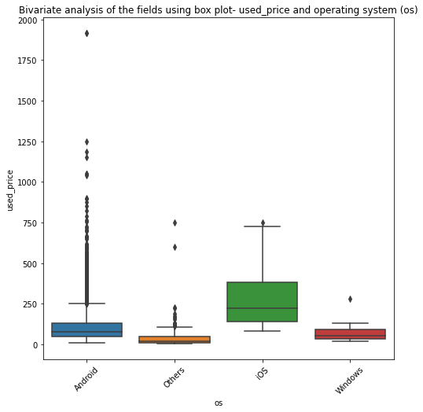

```python
# Set the figure size and title for the plot
plt.figure(figsize=(8,8))
plt.title('Bivariate analysis of the fields using box plot- used_price and operating system (os)')

# Swarm plot for analying the fields - used_price and operating system (os)
sns.boxplot(x="os",y="used_price",data=ReCell_Data)
plt.xticks(rotation=45)
plt.show()
```

#### Multivariate analysis

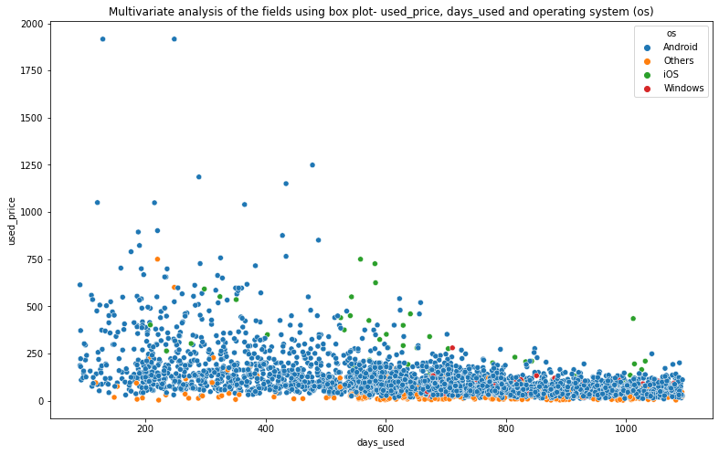

```python
# Set the figure size and title for the plot
plt.figure(figsize=(13, 8))
plt.title('Multivariate analysis of the fields using box plot- used_price, days_used and operating system (os)')

# Scatter plot for analying the fields - used_price, days used and operating system (os)
sns.scatterplot(x="days_used", y="used_price",hue="os", data=ReCell_Data)
plt.show()
```